# The Secret to Good Red Wine

The dataset contains red wines with the chemical properties of the wine. At least 3 wine experts rated the quality of each wine, providing a rating between 0 (very bad) and 10 (very excellent).

Input variables (based on physicochemical tests):  
1 - fixed acidity (tartaric acid - g / dm^3)  
2 - volatile acidity (acetic acid - g / dm^3)  
3 - citric acid (g / dm^3)  
4 - residual sugar (g / dm^3)  
5 - chlorides (sodium chloride - g / dm^3  
6 - free sulfur dioxide (mg / dm^3)  
7 - total sulfur dioxide (mg / dm^3)  
8 - density (g / cm^3)  
9 - pH  
10 - sulphates (potassium sulphate - g / dm3)  
11 - alcohol (% by volume)  
Output variable (based on sensory data):  
12 - quality (score between 0 and 10)

## Univariate Plots Section

### Structure and summary of the data

```
## 'data.frame':    1599 obs. of  13 variables:
##  $ X                   : int  1 2 3 4 5 6 7 8 9 10 ...
##  $ fixed.acidity       : num  7.4 7.8 7.8 11.2 7.4 7.4 7.9 7.3 7.8 7.5 ...
##  $ volatile.acidity    : num  0.7 0.88 0.76 0.28 0.7 0.66 0.6 0.65 0.58 0.5 ...
##  $ citric.acid         : num  0 0 0.04 0.56 0 0 0.06 0 0.02 0.36 ...
##  $ residual.sugar      : num  1.9 2.6 2.3 1.9 1.9 1.8 1.6 1.2 2 6.1 ...
##  $ chlorides           : num  0.076 0.098 0.092 0.075 0.076 0.075 0.069 0.065 0.073 0.071 ...
##  $ free.sulfur.dioxide : num  11 25 15 17 11 13 15 15 9 17 ...
##  $ total.sulfur.dioxide: num  34 67 54 60 34 40 59 21 18 102 ...
##  $ density             : num  0.998 0.997 0.997 0.998 0.998 ...
##  $ pH                  : num  3.51 3.2 3.26 3.16 3.51 3.51 3.3 3.39 3.36 3.35 ...
##  $ sulphates           : num  0.56 0.68 0.65 0.58 0.56 0.56 0.46 0.47 0.57 0.8 ...
##  $ alcohol             : num  9.4 9.8 9.8 9.8 9.4 9.4 9.4 10 9.5 10.5 ...
##  $ quality             : int  5 5 5 6 5 5 5 7 7 5 ...
```

```
##        X          fixed.acidity   volatile.acidity  citric.acid
##  Min.   :   1.0   Min.   : 4.60   Min.   :0.1200   Min.   :0.000
##  1st Qu.: 400.5   1st Qu.: 7.10   1st Qu.:0.3900   1st Qu.:0.090
##  Median : 800.0   Median : 7.90   Median :0.5200   Median :0.260
##  Mean   : 800.0   Mean   : 8.32   Mean   :0.5278   Mean   :0.271
##  3rd Qu.:1199.5   3rd Qu.: 9.20   3rd Qu.:0.6400   3rd Qu.:0.420
##  Max.   :1599.0   Max.   :15.90   Max.   :1.5800   Max.   :1.000
##  residual.sugar     chlorides       free.sulfur.dioxide
##  Min.   : 0.900   Min.   :0.01200   Min.   : 1.00
##  1st Qu.: 1.900   1st Qu.:0.07000   1st Qu.: 7.00
##  Median : 2.200   Median :0.07900   Median :14.00
##  Mean   : 2.539   Mean   :0.08747   Mean   :15.87
##  3rd Qu.: 2.600   3rd Qu.:0.09000   3rd Qu.:21.00
##  Max.   :15.500   Max.   :0.61100   Max.   :72.00
##  total.sulfur.dioxide    density             pH          sulphates
##  Min.   :  6.00       Min.   :0.9901   Min.   :2.740   Min.   :0.3300
##  1st Qu.: 22.00       1st Qu.:0.9956   1st Qu.:3.210   1st Qu.:0.5500
##  Median : 38.00       Median :0.9968   Median :3.310   Median :0.6200
##  Mean   : 46.47       Mean   :0.9967   Mean   :3.311   Mean   :0.6581
##  3rd Qu.: 62.00       3rd Qu.:0.9978   3rd Qu.:3.400   3rd Qu.:0.7300
##  Max.   :289.00       Max.   :1.0037   Max.   :4.010   Max.   :2.0000
##     alcohol         quality
##  Min.   : 8.40   Min.   :3.000
##  1st Qu.: 9.50   1st Qu.:5.000
##  Median :10.20   Median :6.000
##  Mean   :10.42   Mean   :5.636
##  3rd Qu.:11.10   3rd Qu.:6.000
##  Max.   :14.90   Max.   :8.000
```

```
## [1] 0
```

This data consists 1599 observations and 13 columns, and with the 1st column being an index, there are 12 variables. No missing value was found.

#### Distribution: Fixed Acidity

**Fixed Acidity**: most acids involved with wine or fixed or nonvolatile (do not evaporate readily)

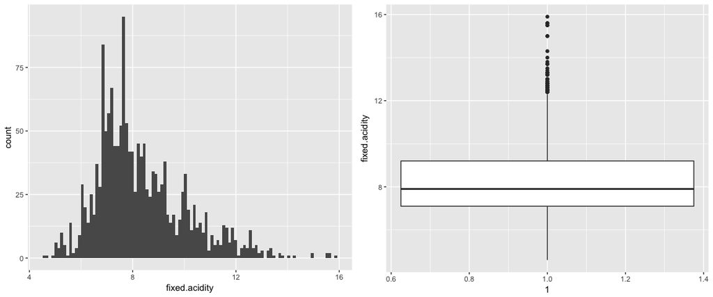

```
##    Min. 1st Qu.  Median    Mean 3rd Qu.    Max.
##    4.60    7.10    7.90    8.32    9.20   15.90
```

Distribution of fixed acidity is slightly right-skewed, and its peak marks around 7 and 8. It contains many outliers, creating a huge gap between the 3rd quartile(9.20) and max number(15.90) compread to the difference between the minimum number(4.60) and the 1st quartile(7.10).

#### Distribution: Volatile Acidity

**Volatile Acidity**: the amount of acetic acid in wine, which at too high of levels can lead to an unpleasant, vinegar taste

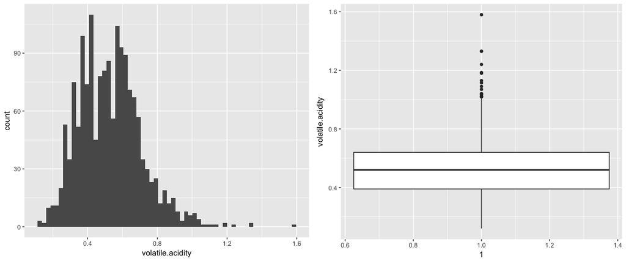

```
##    Min. 1st Qu.  Median    Mean 3rd Qu.    Max.
##  0.1200  0.3900  0.5200  0.5278  0.6400  1.5800
```

Right skewed distribution. I also see a few outliers. Let’s investigate the furthest outlier.

```
##      X fixed.acidity volatile.acidity citric.acid residual.sugar chlorides
## 1 1300           7.6             1.58           0            2.1     0.137
##   free.sulfur.dioxide total.sulfur.dioxide density  pH sulphates alcohol
## 1                   5                    9 0.99476 3.5       0.4    10.9
##   quality
## 1       3
```

It doesn’t look like I need to remove it for now, but I also see that the quality is scored “3”, which is the worst in this dataset and backs up the description of this attribute.

#### Distribution: Citric Acid

**Citric Acid**: found in small quantities, citric acid can add ‘freshness’ and flavor to wines

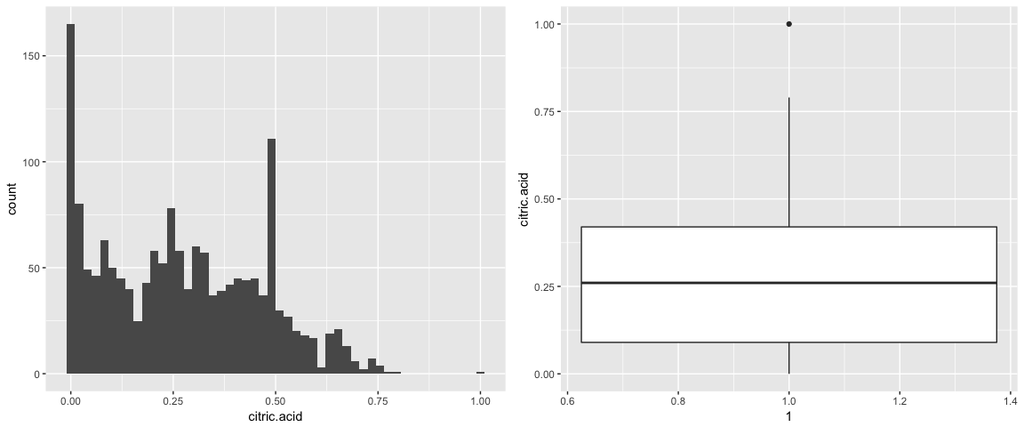

```
##    Min. 1st Qu.  Median    Mean 3rd Qu.    Max.
##   0.000   0.090   0.260   0.271   0.420   1.000
```

This is far from normal distribution. The highest peak is actually at 0, and the second highest at 0.5. I wonder what that outlier looks like:

```
##     X fixed.acidity volatile.acidity citric.acid residual.sugar chlorides
## 1 152           9.2             0.52           1            3.4      0.61
##   free.sulfur.dioxide total.sulfur.dioxide density   pH sulphates alcohol
## 1                  32                   69  0.9996 2.74         2     9.4
##   quality
## 1       4
```

It doesn’t seem like that high level of this attribute contributes to the quality of wine.

#### Distribution: Residual Sugar

**Residual Sugar**: the amount of sugar remaining after fermentation stops, it’s rare to find wines with less than 1 gram/liter and wines with greater than 45 grams/liter are considered sweet

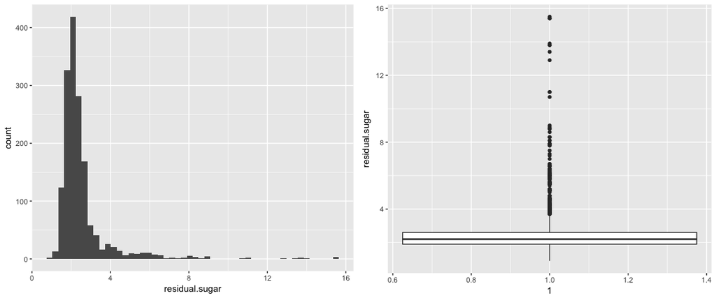

```
##    Min. 1st Qu.  Median    Mean 3rd Qu.    Max.
##   0.900   1.900   2.200   2.539   2.600  15.500
```

So many outliers and heavely skewed. The majority is distributed around 1.9 to 2.6, and the tail of outliers goes out far away till 15.5. What does it look like if I removed all the extremes? I’ll plot a distribution of IQR.

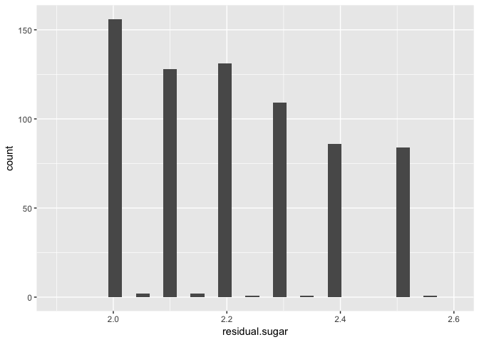

This tells me the differnce in the IQR is pretty moderate, except that I see alarmingly low count in numbers in 2 decimal places (i.g. 2.05, 2.15 etc.). What makes the low ones exceptionally low? I also want to see what happens when I log-transform the original histogram:

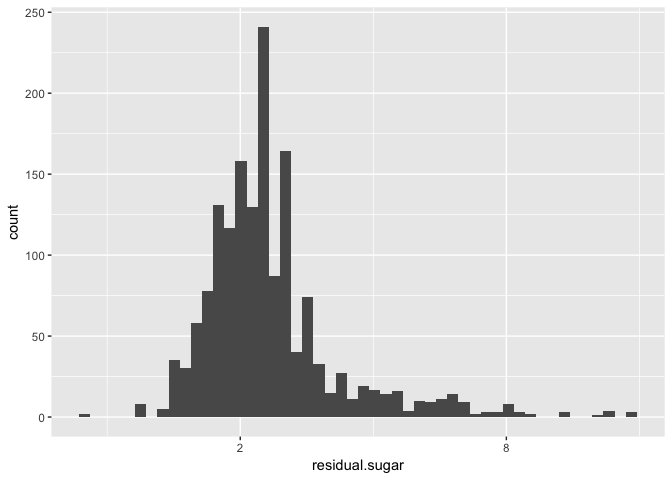

```
##     Min.  1st Qu.   Median     Mean  3rd Qu.     Max.
## -0.04576  0.27875  0.34242  0.36925  0.41497  1.19033
```

This looks much better, though it still has a long tail on the right side.

#### Distribution: Chlorides

**Chlorides**: the amount of salt in the wine

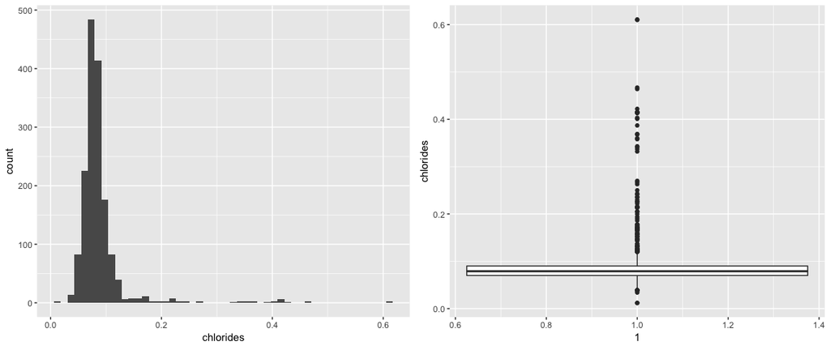

```
##    Min. 1st Qu.  Median    Mean 3rd Qu.    Max.
## 0.01200 0.07000 0.07900 0.08747 0.09000 0.61100
```

Again, many outliers. Here’s what happens when I log-transform the histogram.

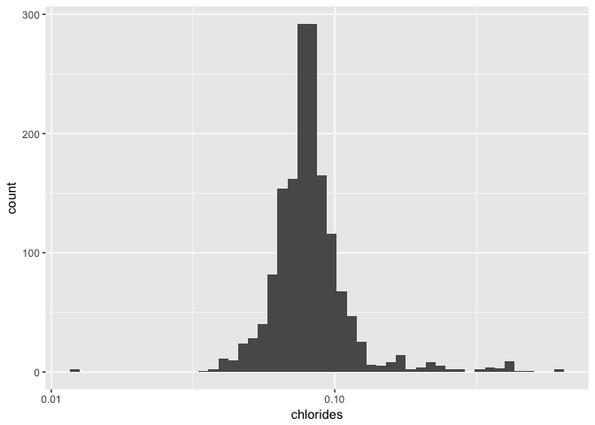

Looks more normal, and the majority are around 0.075 to 0.1.

#### Distribution: Free Sulfur Dioxide

**Free Sulfur Dioxide**: the free form of SO2 exists in equilibrium between molecular SO2 (as a dissolved gas) and bisulfite ion; it prevents microbial growth and the oxidation of wine

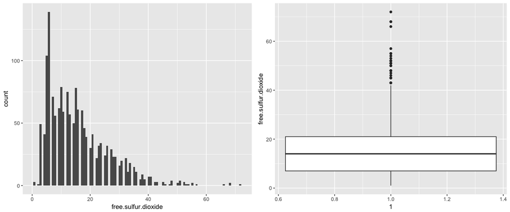

```
##    Min. 1st Qu.  Median    Mean 3rd Qu.    Max.
##    1.00    7.00   14.00   15.87   21.00   72.00
```

Right skewed distribution with many outliers.

#### Distribution: Total Sulfur Dioxide

**Total Sulfur Dioxide**: amount of free and bound forms of S02; in low concentrations, SO2 is mostly undetectable in wine, but at free SO2 concentrations over 50 ppm, SO2 becomes evident in the nose and taste of wine

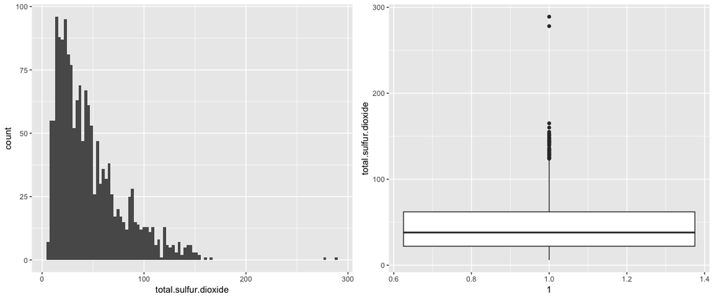

```
##    Min. 1st Qu.  Median    Mean 3rd Qu.    Max.
##    6.00   22.00   38.00   46.47   62.00  289.00
```

Heavely skewed again, and there are extreme outliers. If I take out those two outliers:

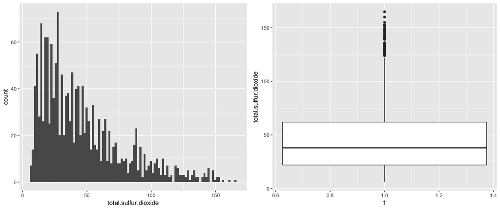

When I look at the distribution in log10 scale:

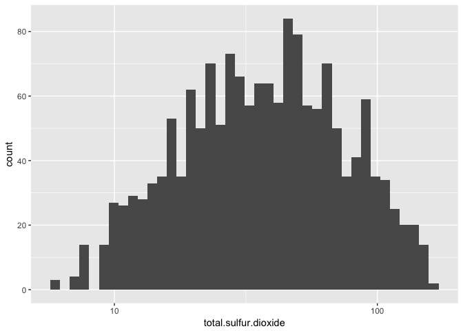

This is closer to a normal distribution, with the highest count around 40.

#### Distribution: Density

**Density**: the density of water is close to that of water depending on the percent alcohol and sugar content

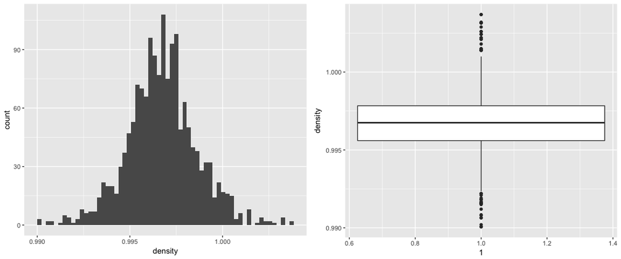

```
##    Min. 1st Qu.  Median    Mean 3rd Qu.    Max.
##  0.9901  0.9956  0.9968  0.9967  0.9978  1.0037
```

This is a better looking distribution. Median 0.9968 and Mean 0.9967 so close to gether, this is almost a normal distribution.

#### Distribution: pH

**pH**: describes how acidic or basic a wine is on a scale from 0 (very acidic) to 14 (very basic); most wines are between 3-4 on the pH scale

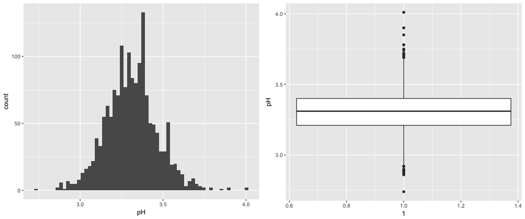

```
##    Min. 1st Qu.  Median    Mean 3rd Qu.    Max.
##   2.740   3.210   3.310   3.311   3.400   4.010
```

Another good looking distribution that is close to normal. Outliers on both end that I can possible take out.

#### Distribution: Sulphates

**Sulphates**: a wine additive which can contribute to sulfur dioxide gas (S02) levels, wich acts as an antimicrobial and antioxidant

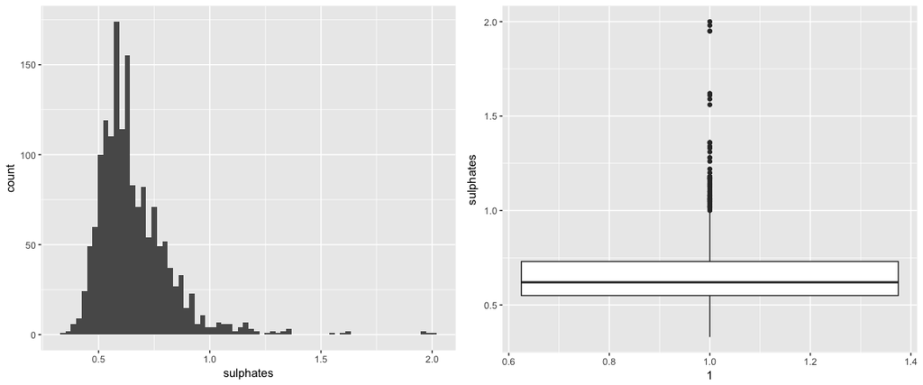

```
##    Min. 1st Qu.  Median    Mean 3rd Qu.    Max.
##  0.3300  0.5500  0.6200  0.6581  0.7300  2.0000
```

When I log-scale it:

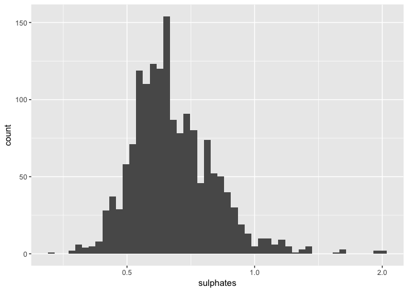

Median stands out in the distribution and gradually decreases to 1, and after that is a long tail of outliers.

#### Distribution: Alcohol

**Alcohol**: the percent alcohol content of the wine

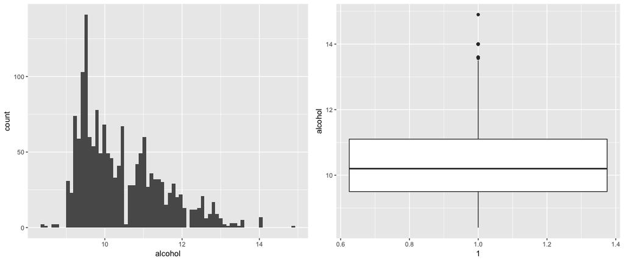

```
##    Min. 1st Qu.  Median    Mean 3rd Qu.    Max.
##    8.40    9.50   10.20   10.42   11.10   14.90
```

The count decreases as the level of alcohol increases. The peak is between 9 and 10.

#### Distribution: Quality

**Quality**: score between 0 and 10

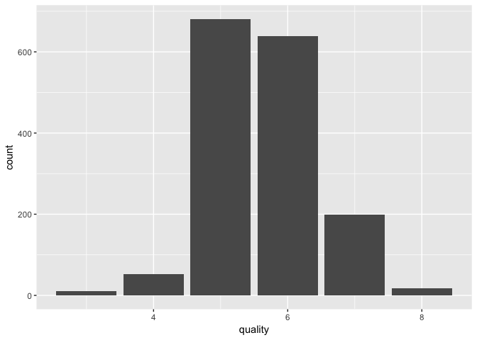

```
##    Min. 1st Qu.  Median    Mean 3rd Qu.    Max.
##   3.000   5.000   6.000   5.636   6.000   8.000
```

I can see that the majority of wine were scored between 5 and 6. No wines were below 3 or above 8.

#### Distribution: Low and High Quality

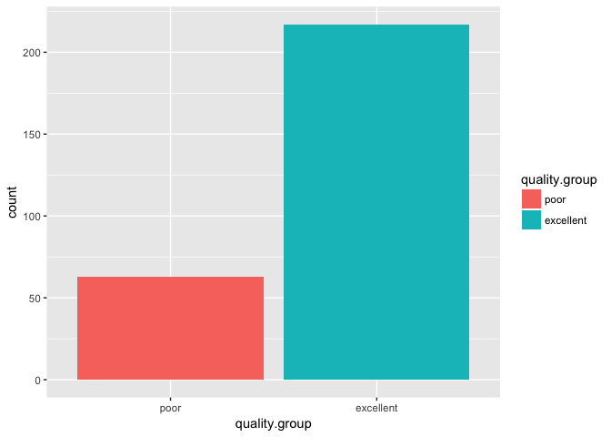

When I exclude the quality 5 and 6, and combined the 3 and 4 into a class called “poor” and 7 and 8 into a class “excellent”, I see most were rated high than low.

## Univariate Analysis

Structure of Dataset

The dataset has 13 columns and 1599 rows, and has 12 variables. 1 categorical variable, which is “quality”, and the rest are continuous numerical variables.The quality scores go from 0 (lowest) to 10 (highest). Most wines score between 5 and 6, and few are labels as excellent or poor.

Main Feature of Interest in the Dataset

The main feature of interest would be attributes that are directly correlated to the quality of wines. Attributes such as volatile acidity would have quite direct influence. For example, volatile acidity too high of levels can lead to an unpleasant, and [Waterhouse Lab](http://waterhouse.ucdavis.edu/whats-in-wine/fixed-acidity) explains that acids impart the sourness or tartness that is a fundamental feature in wine taste.

Other features in the Dataset to Investigate

Finding combinations of attributes that make good wine.

Unusual Distributions and Its Handling

On residual sugar plot, I set the x limit within IQR to take a closer look at the majority, because it was heavily right skewed and there were so many outliers. I then log-tranformed it to look at the original plot again to better look at the tail of the distribution. The same process was applied to total sulfur dioxide. I also log-transformed the chlorides and sulphates plots to since their right skewed distributions had quite wide ranges.

## Bivariate Plots Section

### Comparison of Quality by Attributes

Before getting into each plot, I’m going to take a look at the whole dataset for over-all comparison.

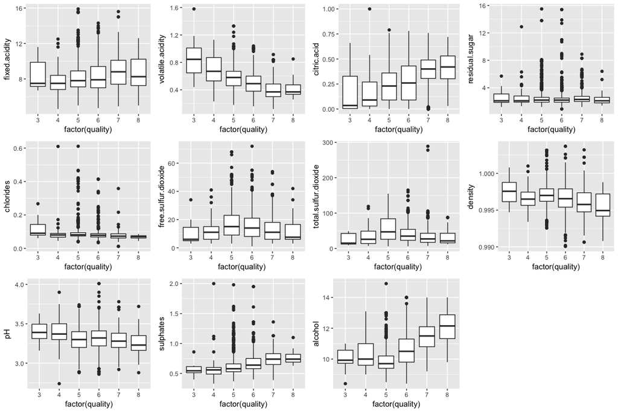

From this comparison, the attributes that may positively affect the quality of wine are volatile acidity, citric acid, density, pH, sulphates, and alcohol.

#### Focusing on the Extremes

Because most of the wines were rated 5 and 6, it’s a little hard to see which attributes make “poor” and “excellent” wines. I’m going to subset the data so I can focus on those extreme cases.

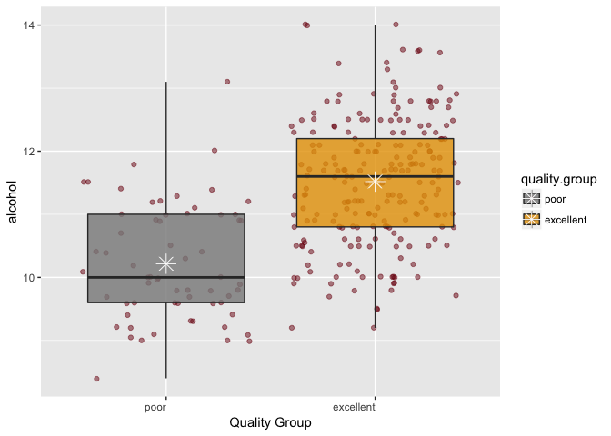

This is much easier to see the difference in the quality. I’m going to check the rest of attributes.

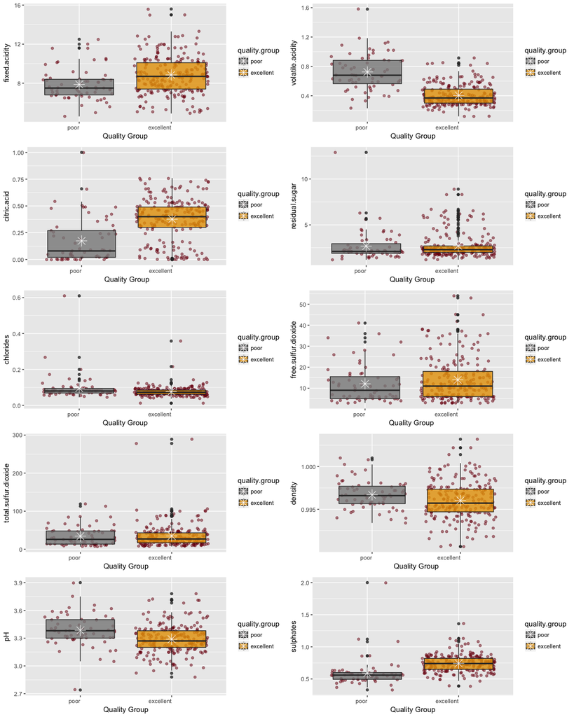

With this plot, I can see the bigger quality distinctions are observed with:  
- alcohol (excellent wines have higher alcohol)  
- volatile acidity (excellent wines have lower volatile acidity)  
- citric acidity (excellent wines have higher citric acid)  
- sulphates (excellent wines have higher sulphates)

#### Correlation Plot

First running on the original dataset, then comparing it with the one without the “normal” wines.

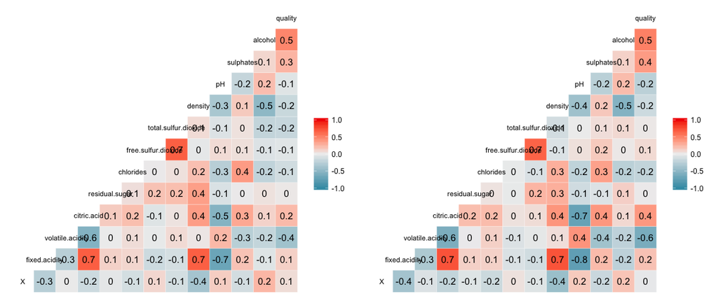

The first one on the left confirms my observation on alcohol with its stronger correlation with quality. The second on on the right also confirms my observation on the boxplots comparison where alcohol, volatile acidity, citric acid, and sulphates made difference in extremes. Some numbers of attributes with each other also changed, and when they did, most of the correlation became stronger.

## Bivariate Analysis

Observations in This Part of the Investigation

First, I investigated the relationship of quality and each attribute, but the initial plot that displays all observations showed that the only attribute with a decent correlation was alcohol — the quality seems to go up as the alcohol level did as well. The boxplot confirmed that the median and mean did indeed went up as the quality did, but only from score 5 to 8. The correlation test confirmed it was approximately 0.48. But when I removed the wines scored 5 and 6 from the plot to focus on the ones scored below 5 and above 6, I found there were more attributes that produced noteworthy difference in quality.

I also want to point out the relationships with other attributes besides the quality. Some had stronger correlations with each other than with the quality, and I wonder if that indicates the attributes’ influence on each other and that’s what determines the quality of wine. They also got stronger when I used a subset without the scores 5 and 6.

The Strongest Relationship of Attributes

The ones with stronger correlations from the original dataset (-0.7 > and 0.7 <):  
- pH and fixed acidity  
- density and fixed acidity  
- total sulfur dioxide and free fulfur dioxide  
- citric acid and fixed acidity

## Multivariate Plots Section

First, I’m going to compare alcohol with density by excellent and poor wines. At this point, since my main interest is finding out what makes these distinct wines, I’ll exclude the quality 5 and 6 from these plots.

#### Density and Alcohol by Quality

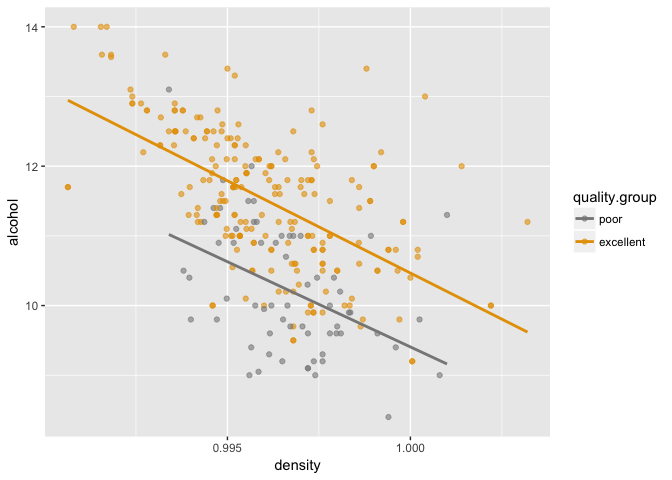

```
##
##  Pearson's product-moment correlation
##
## data:  no.normal$density and no.normal$alcohol
## t = -10.925, df = 278, p-value < 2.2e-16
## alternative hypothesis: true correlation is not equal to 0
## 95 percent confidence interval:
##  -0.6251305 -0.4604302
## sample estimates:
##       cor
## -0.548071
```

Density has the strongest correlation with alcohol, and the combination shows a clear seperation between the two quality groups. Now I’m going to compare the four pairs with the strongest correlations.  
- pH and fixed acidity  
- density and fixed acidity  
- total sulfur dioxide and free fulfur dioxide  
- citric acid and fixed acidity

#### pH and Fixed Acidity

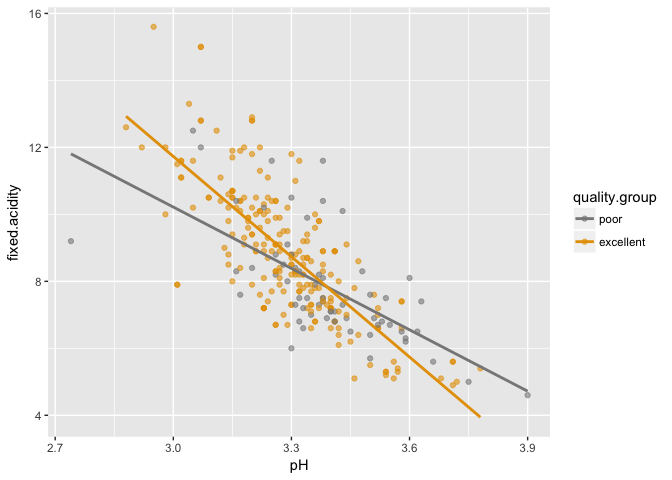

```
##
##  Pearson's product-moment correlation
##
## data:  no.normal$pH and no.normal$fixed.acidity
## t = -19.005, df = 278, p-value < 2.2e-16
## alternative hypothesis: true correlation is not equal to 0
## 95 percent confidence interval:
##  -0.7985685 -0.6958055
## sample estimates:
##        cor
## -0.7517146
```

They have a pretty strong correlation with each other, but that doesn’t seem to directly affect on the quality.

#### Density and Fixed Acidity

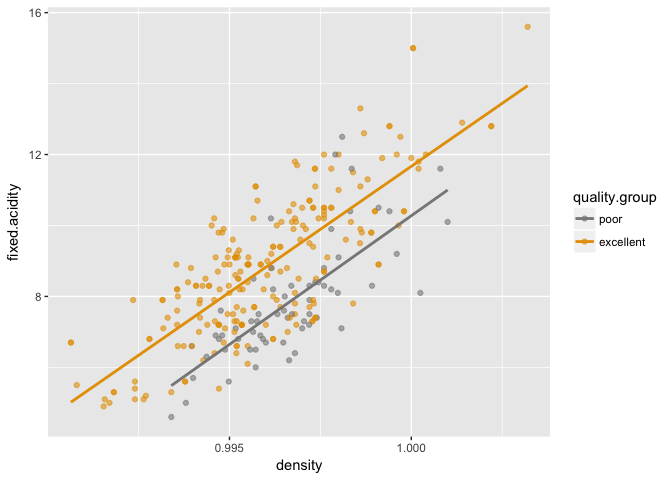

```
##
##  Pearson's product-moment correlation
##
## data:  no.normal$density and no.normal$fixed.acidity
## t = 17.476, df = 278, p-value < 2.2e-16
## alternative hypothesis: true correlation is not equal to 0
## 95 percent confidence interval:
##  0.6624851 0.7750110
## sample estimates:
##       cor
## 0.7235198
```

Here is another strong, correlation, and the seperation of the two quality groups is more apparent.

#### Total Sulfur Dioxide and Free Sulfur Dioxide

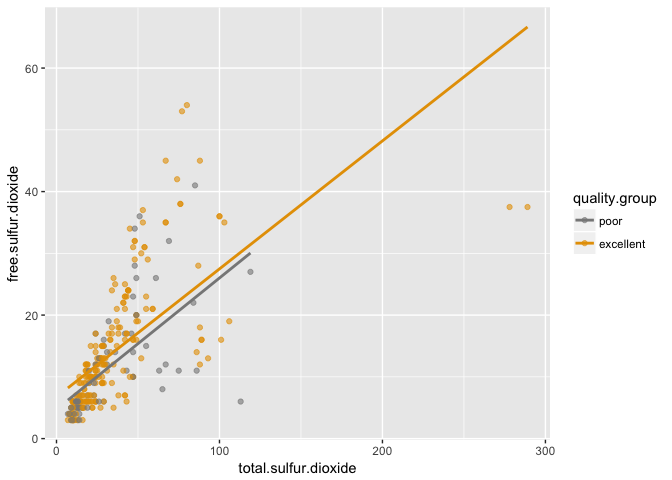

```
##
##  Pearson's product-moment correlation
##
## data:  no.normal$total.sulfur.dioxide and no.normal$free.sulfur.dioxide
## t = 14.286, df = 278, p-value < 2.2e-16
## alternative hypothesis: true correlation is not equal to 0
## 95 percent confidence interval:
##  0.5774698 0.7134541
## sample estimates:
##       cor
## 0.6506477
```

If I excluded the two outliers on the right:

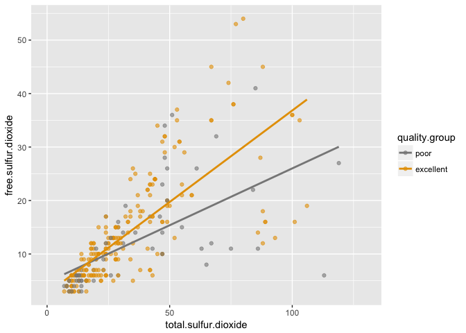

Most are concentrated towads 0, but as the points spread out more, the level on both attributes increases. In this relationship, however, I don’t see anything significant that are correlated to quality.

#### Citric Acid and Fixed Acidity

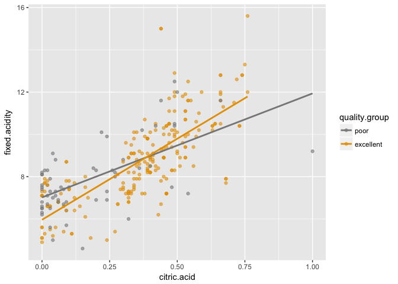

```
##
##  Pearson's product-moment correlation
##
## data:  no.normal$citric.acid and no.normal$fixed.acidity
## t = 17.565, df = 278, p-value < 2.2e-16
## alternative hypothesis: true correlation is not equal to 0
## 95 percent confidence interval:
##  0.6645529 0.7764821
## sample estimates:
##       cor
## 0.7252755
```

And if I excluded outliers on both axis:

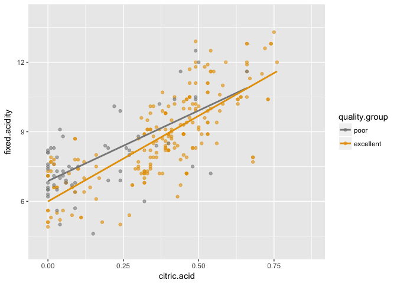

Citric acid and fixed acidity have a strong correlation of 0.73. Although the line shows small seperation of the quality groups, the poor group seems to be concentrated on fixed acidity level 6-9 and citric acid level 0 to 0.125., while the excellent group is concentrated in the middle of the plot.

## Multivariate Analysis

Observations in This Part of the Investigation

From the previous analysis, I found that alcohol had the strongest correlation with quality, so I wanted to choose an attribute that had the strongest correlation with alcohol, and run their relationship by quality. The plot had a good seperation between excellent and poor wines. I also checked where these quality groups were in each attributes pairs that had the strongest correlations, and density and fixed acidity also had a strong correlation with quality.

Interesting or Surprising Interactions Between Features

It was interesting to see that some pairs would have a strong correlation with each other, but that doesn’t always contribute to quality. This investigation has become a lot more complex and difficult than I expected.